# tidy-model

Jissel Maldonado

2025-02-16

## Introduction

This R Markdown document demonstrates my abilities to use models for data analysis using a dataset collected on crickets.

## What is that sound?

In this report, we examine what factors predict a cricket’s chirp rate.

```
##              species        temp            rate
##  O. exclamationis:14   Min.   :17.20   Min.   : 44.30
##  O. niveus       :17   1st Qu.:20.80   1st Qu.: 59.45
##                        Median :24.00   Median : 76.20
##                        Mean   :23.76   Mean   : 72.89
##                        3rd Qu.:26.35   3rd Qu.: 85.25
##                        Max.   :30.40   Max.   :101.70
```

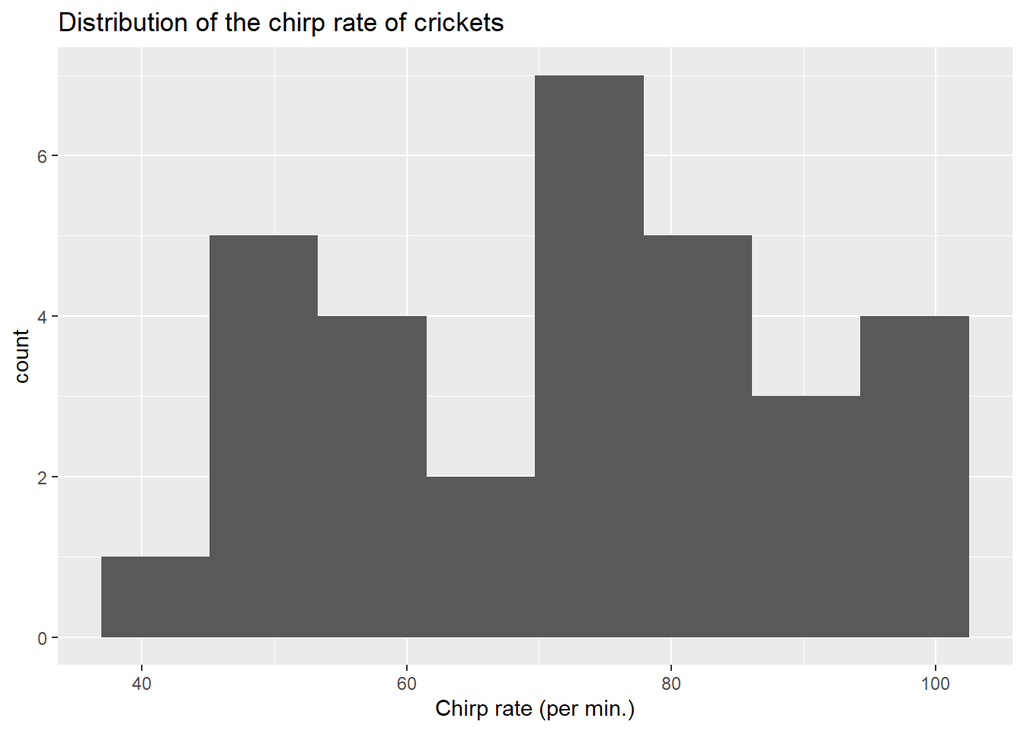

Summary:

Number of observations: 31 Number of species: 2 Temperature range: min of 17.20, max of 30.40 Mean rate of chirping: 72.89

## Temperature affects chirp rate

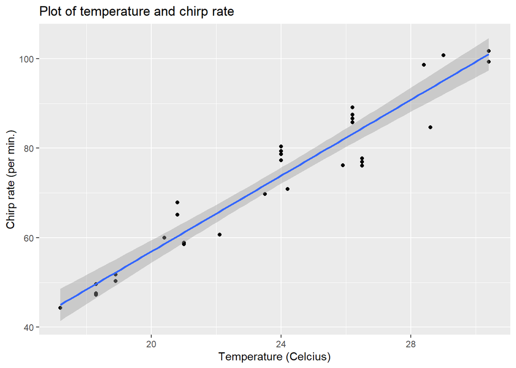

```
##
## Call:
## lm(formula = rate ~ temp, data = crickets)
##
## Residuals:
##     Min      1Q  Median      3Q     Max
## -8.7044 -2.5789 -0.4466  4.5353  7.5916
##
## Coefficients:
##             Estimate Std. Error t value Pr(>|t|)
## (Intercept) -27.9476     5.5937  -4.996 2.56e-05 ***
## temp          4.2431     0.2325  18.251  < 2e-16 ***
## ---
## Signif. codes:  0 '***' 0.001 '**' 0.01 '*' 0.05 '.' 0.1 ' ' 1
##
## Residual standard error: 4.868 on 29 degrees of freedom
## Multiple R-squared:  0.9199, Adjusted R-squared:  0.9171
## F-statistic: 333.1 on 1 and 29 DF,  p-value: < 2.2e-16
```

Based on a scatter plot of temperature and chirping and a correlation test, it seems that as temperature increases one degree, the rate of chirping increases about 4.2 chirps per minute.

## Species-specific effects of temperature on chirping

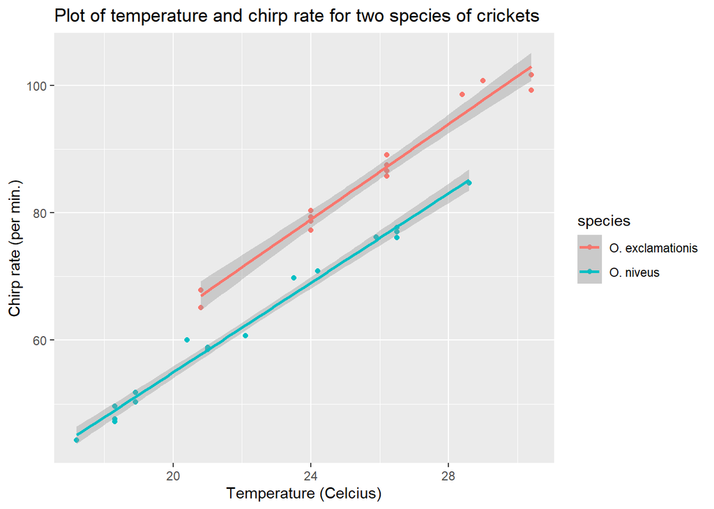

```
##
## Call:
## lm(formula = rate ~ temp + species, data = crickets)
##
## Residuals:
##     Min      1Q  Median      3Q     Max
## -3.0128 -1.1296 -0.3912  0.9650  3.7800
##
## Coefficients:
##                   Estimate Std. Error t value Pr(>|t|)
## (Intercept)       -7.21091    2.55094  -2.827  0.00858 **
## temp               3.60275    0.09729  37.032  < 2e-16 ***
## speciesO. niveus -10.06529    0.73526 -13.689 6.27e-14 ***
## ---
## Signif. codes:  0 '***' 0.001 '**' 0.01 '*' 0.05 '.' 0.1 ' ' 1
##
## Residual standard error: 1.786 on 28 degrees of freedom
## Multiple R-squared:  0.9896, Adjusted R-squared:  0.9888
## F-statistic:  1331 on 2 and 28 DF,  p-value: < 2.2e-16
```

Based on the scatter plot of temperature, chirping, species, and a correlation test, it seems that as temperature increases one degree, the rate of chirping increases about 3.6 chirps per minute. O. exclamationis has a chirp rate 10 chirps per minute higher than O. niveus. Additionally, the model accounts for about 99% of the variance in the data.

## Interactions

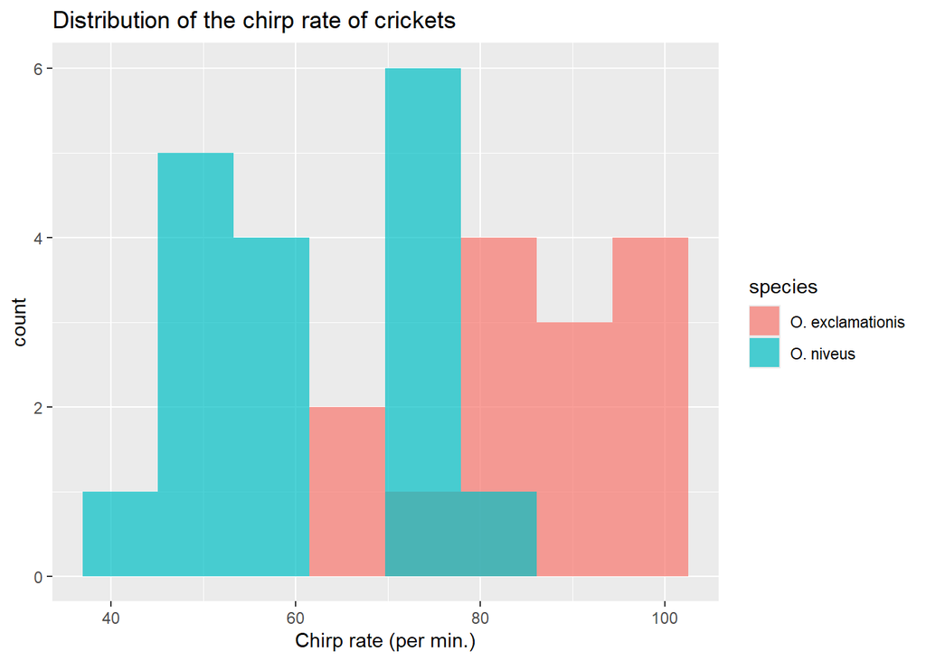

The O. exclamationis and O. niveus species occupy different temperature zones, which potentially impacts chirp rate.

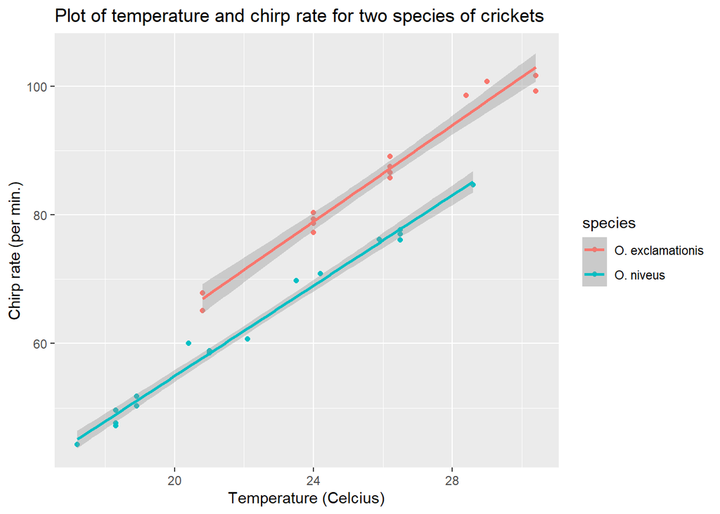

```
##
## Call:
## lm(formula = rate ~ temp + species + temp:species, data = crickets)
##
## Residuals:
##     Min      1Q  Median      3Q     Max
## -3.7031 -1.3417 -0.1235  0.8100  3.6330
##
## Coefficients:
##                       Estimate Std. Error t value Pr(>|t|)
## (Intercept)           -11.0408     4.1515  -2.659    0.013 *
## temp                    3.7514     0.1601  23.429   <2e-16 ***
## speciesO. niveus       -4.3484     4.9617  -0.876    0.389
## temp:speciesO. niveus  -0.2340     0.2009  -1.165    0.254
## ---
## Signif. codes:  0 '***' 0.001 '**' 0.01 '*' 0.05 '.' 0.1 ' ' 1
##
## Residual standard error: 1.775 on 27 degrees of freedom
## Multiple R-squared:  0.9901, Adjusted R-squared:  0.989
## F-statistic: 898.9 on 3 and 27 DF,  p-value: < 2.2e-16
```

```
## Analysis of Variance Table
##
## Model 1: rate ~ temp + species
## Model 2: rate ~ temp + species + temp:species
##   Res.Df    RSS Df Sum of Sq     F Pr(>F)
## 1     28 89.350
## 2     27 85.074  1    4.2758 1.357 0.2542
```

The species-specific model and species-temperature interaction model are not statistically significantly different with a p-value greater than 0.05. Therefore, we can rely on the species-specific model for prediction about chirp rates.

## Visualize and model diamond worth using price, carat, and cut

We will now examine what factors determine a diamond’s worth.

```
##      carat               cut        color        clarity          depth
##  Min.   :0.2000   Fair     : 1610   D: 6775   SI1    :13065   Min.   :43.00
##  1st Qu.:0.4000   Good     : 4906   E: 9797   VS2    :12258   1st Qu.:61.00
##  Median :0.7000   Very Good:12082   F: 9542   SI2    : 9194   Median :61.80
##  Mean   :0.7979   Premium  :13791   G:11292   VS1    : 8171   Mean   :61.75
##  3rd Qu.:1.0400   Ideal    :21551   H: 8304   VVS2   : 5066   3rd Qu.:62.50
##  Max.   :5.0100                     I: 5422   VVS1   : 3655   Max.   :79.00
##                                     J: 2808   (Other): 2531
##      table           price             x                y
##  Min.   :43.00   Min.   :  326   Min.   : 0.000   Min.   : 0.000
##  1st Qu.:56.00   1st Qu.:  950   1st Qu.: 4.710   1st Qu.: 4.720
##  Median :57.00   Median : 2401   Median : 5.700   Median : 5.710
##  Mean   :57.46   Mean   : 3933   Mean   : 5.731   Mean   : 5.735
##  3rd Qu.:59.00   3rd Qu.: 5324   3rd Qu.: 6.540   3rd Qu.: 6.540
##  Max.   :95.00   Max.   :18823   Max.   :10.740   Max.   :58.900
##
##        z
##  Min.   : 0.000
##  1st Qu.: 2.910
##  Median : 3.530
##  Mean   : 3.539
##  3rd Qu.: 4.040
##  Max.   :31.800
##
```

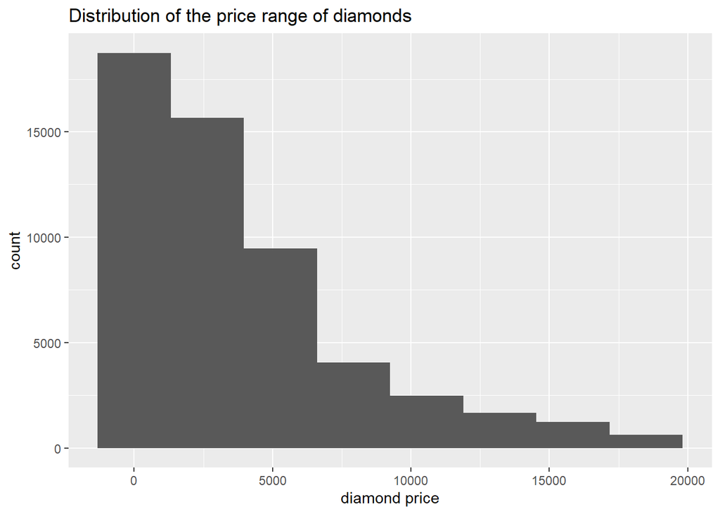

Summary: 5 cuts, minimum carat - 0.2 and max carat - 5.01, mean price of 3933

## carat affects diamond price

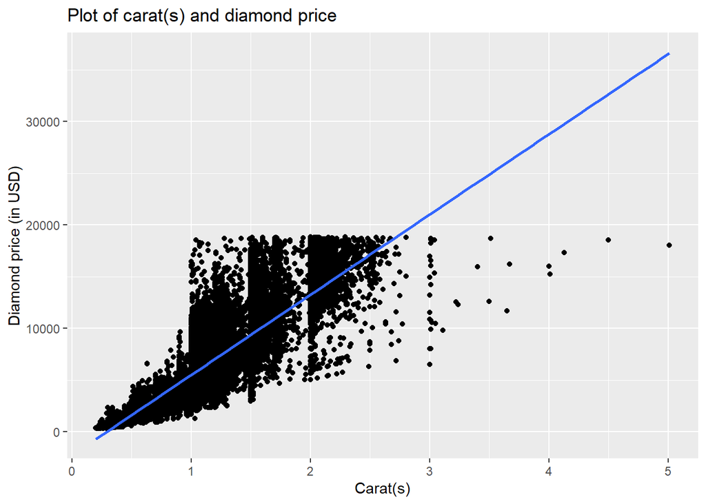

```
##
## Call:
## lm(formula = price ~ carat, data = diamonds)
##
## Residuals:
##      Min       1Q   Median       3Q      Max
## -18585.3   -804.8    -18.9    537.4  12731.7
##
## Coefficients:
##             Estimate Std. Error t value Pr(>|t|)
## (Intercept) -2256.36      13.06  -172.8   <2e-16 ***
## carat        7756.43      14.07   551.4   <2e-16 ***
## ---
## Signif. codes:  0 '***' 0.001 '**' 0.01 '*' 0.05 '.' 0.1 ' ' 1
##
## Residual standard error: 1549 on 53938 degrees of freedom
## Multiple R-squared:  0.8493, Adjusted R-squared:  0.8493
## F-statistic: 3.041e+05 on 1 and 53938 DF,  p-value: < 2.2e-16
```

Based on the scatter plot, as the weight of the diamond increases by 1 carat, diamond price increases by about 7756 USD.

## cut-specific effects of carat(s) on price

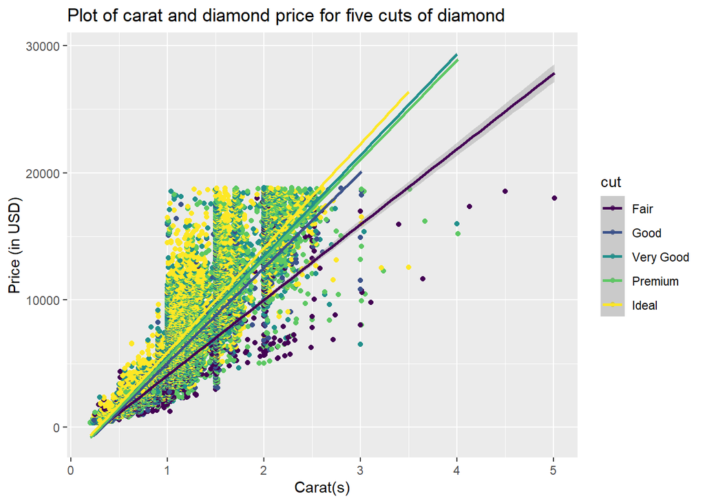

```
##
## Call:
## lm(formula = price ~ carat + cut, data = diamonds)
##
## Residuals:
##      Min       1Q   Median       3Q      Max
## -17540.7   -791.6    -37.6    522.1  12721.4
##
## Coefficients:
##             Estimate Std. Error t value Pr(>|t|)
## (Intercept) -3875.47      40.41  -95.91   <2e-16 ***
## carat        7871.08      13.98  563.04   <2e-16 ***
## cut2         1120.33      43.50   25.75   <2e-16 ***
## cut3         1510.14      40.24   37.53   <2e-16 ***
## cut4         1439.08      39.87   36.10   <2e-16 ***
## cut5         1800.92      39.34   45.77   <2e-16 ***
## ---
## Signif. codes:  0 '***' 0.001 '**' 0.01 '*' 0.05 '.' 0.1 ' ' 1
##
## Residual standard error: 1511 on 53934 degrees of freedom
## Multiple R-squared:  0.8565, Adjusted R-squared:  0.8565
## F-statistic: 6.437e+04 on 5 and 53934 DF,  p-value: < 2.2e-16
```

Based on the scatter plot, as the weight of the diamond increases by 1 carat, diamond price increases by about 7871 USD. There is a price difference of about 1120 from fair to good, 1510 from fair to very good, 1439 from fair to premium, and 1800 from fair to ideal. This model accounts for about 85% of the variance in the data.

## Interactions between carat and cut in diamonds

```
##      carat               cut        color        clarity          depth
##  Min.   :0.2000   Fair     : 1610   D: 6775   SI1    :13065   Min.   :43.00
##  1st Qu.:0.4000   Good     : 4906   E: 9797   VS2    :12258   1st Qu.:61.00
##  Median :0.7000   Very Good:12082   F: 9542   SI2    : 9194   Median :61.80
##  Mean   :0.7979   Premium  :13791   G:11292   VS1    : 8171   Mean   :61.75
##  3rd Qu.:1.0400   Ideal    :21551   H: 8304   VVS2   : 5066   3rd Qu.:62.50
##  Max.   :5.0100                     I: 5422   VVS1   : 3655   Max.   :79.00
##                                     J: 2808   (Other): 2531
##      table           price             x                y
##  Min.   :43.00   Min.   :  326   Min.   : 0.000   Min.   : 0.000
##  1st Qu.:56.00   1st Qu.:  950   1st Qu.: 4.710   1st Qu.: 4.720
##  Median :57.00   Median : 2401   Median : 5.700   Median : 5.710
##  Mean   :57.46   Mean   : 3933   Mean   : 5.731   Mean   : 5.735
##  3rd Qu.:59.00   3rd Qu.: 5324   3rd Qu.: 6.540   3rd Qu.: 6.540
##  Max.   :95.00   Max.   :18823   Max.   :10.740   Max.   :58.900
##
##        z
##  Min.   : 0.000
##  1st Qu.: 2.910
##  Median : 3.530
##  Mean   : 3.539
##  3rd Qu.: 4.040
##  Max.   :31.800
##
```

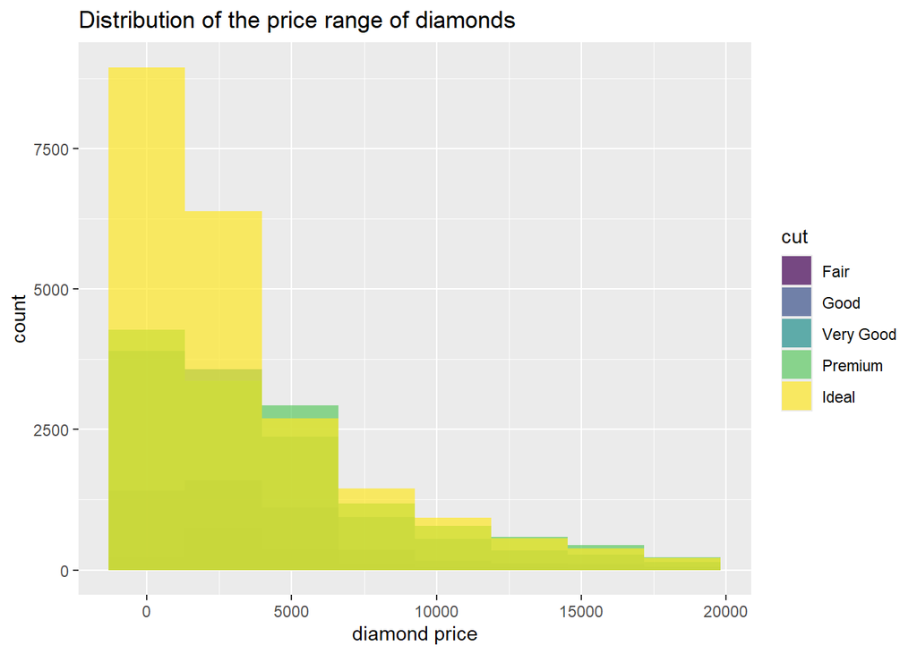

Diamond cuts may be more prevalent in different carats, so the interaction of these two variables may potentially affect price.

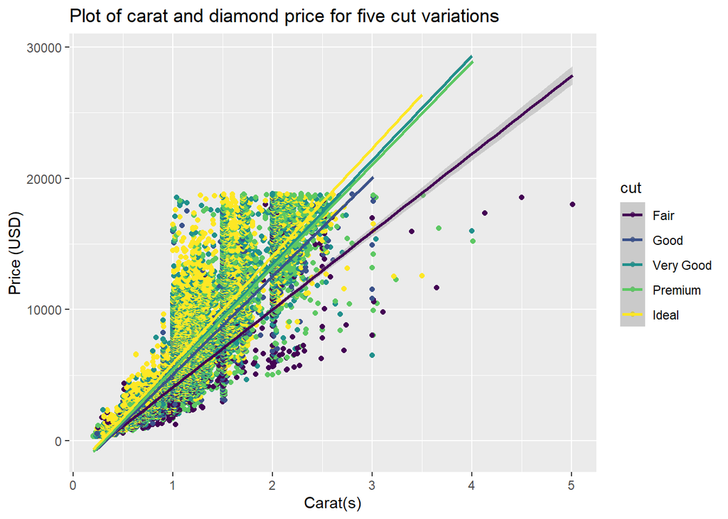

```
##
## Call:
## lm(formula = price ~ carat + cut + carat:cut, data = diamonds)
##
## Residuals:
##      Min       1Q   Median       3Q      Max
## -14878.3   -793.0    -23.0    546.3  12706.2
##
## Coefficients:
##             Estimate Std. Error t value Pr(>|t|)
## (Intercept) -1839.07      84.35 -21.802  < 2e-16 ***
## carat        5924.50      72.31  81.933  < 2e-16 ***
## cut2         -583.65      95.77  -6.094 1.11e-09 ***
## cut3         -578.59      88.73  -6.521 7.06e-11 ***
## cut4         -540.83      88.12  -6.137 8.46e-10 ***
## cut5         -461.30      86.57  -5.329 9.93e-08 ***
## carat:cut2   1555.14      86.30  18.021  < 2e-16 ***
## carat:cut3   2011.48      78.16  25.737  < 2e-16 ***
## carat:cut4   1883.26      76.43  24.641  < 2e-16 ***
## carat:cut5   2267.90      76.05  29.820  < 2e-16 ***
## ---
## Signif. codes:  0 '***' 0.001 '**' 0.01 '*' 0.05 '.' 0.1 ' ' 1
##
## Residual standard error: 1498 on 53930 degrees of freedom
## Multiple R-squared:  0.8591, Adjusted R-squared:  0.859
## F-statistic: 3.653e+04 on 9 and 53930 DF,  p-value: < 2.2e-16
```

```
## Analysis of Variance Table
##
## Model 1: price ~ carat + cut
## Model 2: price ~ carat + cut + carat:cut
##   Res.Df        RSS Df  Sum of Sq      F    Pr(>F)
## 1  53934 1.2321e+11
## 2  53930 1.2099e+11  4 2223124519 247.73 < 2.2e-16 ***
## ---
## Signif. codes:  0 '***' 0.001 '**' 0.01 '*' 0.05 '.' 0.1 ' ' 1
```

The cut-specific model and cut-carat interaction model are statistically significantly different with a p-value less than 0.05. Therefore, we can rely on the cut-carat interaction model for prediction about diamond prices in USD.